# R Workshop Based on Duke MEM by Mine Cetinkaya-Rundel

11 September, 2016

## Outline

- Initial data preparation
- Data investigation
- Basic data visualizations in ggplot
  - scatter plot
  - box plot
  - histogram
  - bar chart
- data munging using dplyr

## Data visualization

## Load data

```r
library(caret)
library(dplyr)
library(ggplot2)
library(plotly)
data("GermanCredit")
```

## Data Preparation

```r
str(GermanCredit)
```

```r
names(GermanCredit)[1:20]
```

```
##  [1] "Duration"                       "Amount"
##  [3] "InstallmentRatePercentage"      "ResidenceDuration"
##  [5] "Age"                            "NumberExistingCredits"
##  [7] "NumberPeopleMaintenance"        "Telephone"
##  [9] "ForeignWorker"                  "Class"
## [11] "CheckingAccountStatus.lt.0"     "CheckingAccountStatus.0.to.200"
## [13] "CheckingAccountStatus.gt.200"   "CheckingAccountStatus.none"
## [15] "CreditHistory.NoCredit.AllPaid" "CreditHistory.ThisBank.AllPaid"
## [17] "CreditHistory.PaidDuly"         "CreditHistory.Delay"
## [19] "CreditHistory.Critical"         "Purpose.NewCar"
```

## Data Preparation cd…

```r
GermanCredit$Sex <-
  GermanCredit$Personal.Male.Divorced.Seperated +
  GermanCredit$Personal.Male.Single +
  GermanCredit$Personal.Male.Married.Widowed

GermanCredit$Sex <- ifelse(GermanCredit$Sex, "Male", "Female")
```

## Data Preparation cd…

```r
GermanCredit$Property <-
  sapply(1:dim(GermanCredit)[1], function(i)
    if(GermanCredit$Property.RealEstate[i]){
      "RealEstate"
    } else if(GermanCredit$Property.Insurance[i]) {
      "Insurance"
    } else if(GermanCredit$Property.CarOther[i]) {
      "CarOther"
    } else {
      "Unknown"
    })
```

## Data Preparation cd…

```r
GermanCredit$Purpose <-
  names(GermanCredit[20:30])[max.col(GermanCredit[20:30])]
```

## Data Preparation cd…

```r
GermanCredit <- GermanCredit[, c(1:7, 10, 63:65)]
str(GermanCredit, width = 80, strict.width = "wrap")
```

```
## 'data.frame':    1000 obs. of  11 variables:
## $ Duration : int 6 48 12 42 24 36 24 36 12 30 ...
## $ Amount : int 1169 5951 2096 7882 4870 9055 2835 6948 3059 5234 ...
## $ InstallmentRatePercentage: int 4 2 2 2 3 2 3 2 2 4 ...
## $ ResidenceDuration : int 4 2 3 4 4 4 4 2 4 2 ...
## $ Age : int 67 22 49 45 53 35 53 35 61 28 ...
## $ NumberExistingCredits : int 2 1 1 1 2 1 1 1 1 2 ...
## $ NumberPeopleMaintenance : int 1 1 2 2 2 2 1 1 1 1 ...
## $ Class : Factor w/ 2 levels "Bad","Good": 2 1 2 2 1 2 2 2 2 1 ...
## $ Sex : chr "Male" "Female" "Male" "Male" ...
## $ Property : chr "RealEstate" "RealEstate" "RealEstate" "Insurance" ...
## $ Purpose : chr "Purpose.Radio.Television" "Purpose.Radio.Television"
##    "Purpose.Education" "Purpose.Furniture.Equipment" ...
```

## Data visualization in R

- Using base R functions
- Using the `ggplot2` package \(\leftarrow\) our focus today
- Using a variety of other packages like `lattice`, `ggvis`, etc.

## The Grammar of Graphics

- Visualisation concept created by Wilkinson (1999)
  - to define the basic elements of a statistical graphic
- Adapted for R by Wickham (2009) who created the `ggplot2` package
  - consistent and compact syntax to describe statistical graphics
  - highly modular as it breaks up graphs into semantic components
- Is not a guide which graph to choose and how to convey information best!

Source: https://rpubs.com/timwinke/ggplot2workshop

## The Grammar of Graphics - Terminology

A statistical graphic is a…

- mapping of **data**
- to **aesthetic attributes** (color, size, xy-position)
- using **geometric objects** (points, lines, bars)
- with data being **statistically transformed** (summarised, log-transformed)
- and mapped onto a specific **facet** and **coordinate system**

## Age vs. Amount

[figure not shown]

- Which data is used as an input?
- What geometric objects are chosen for visualization?
- What variables are mapped onto which attributes?
- What type of scales are used to map data to aesthetics?
- Are the variables statistically transformed before plotting?

## Anatomy of ggplots

```
ggplot(data = [dataframe], aes(x = [var_x], y = [var_y],
       color = [var_for_color], fill = [var_for_fill],
       shape = [var_for_shape])) +
    geom_[some_geom] +
    ... # other options
```

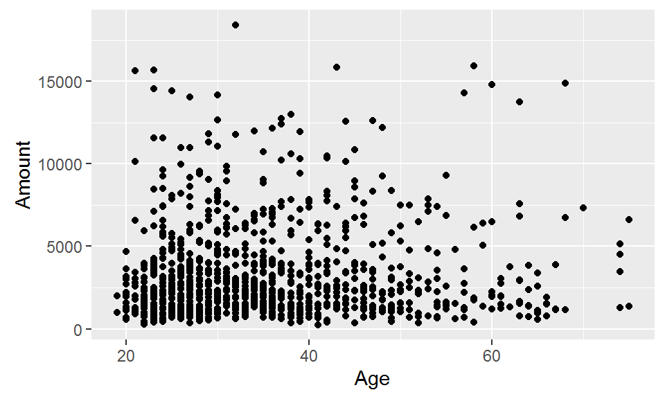

```r
ggplot(data = GermanCredit, aes(x = Age, y = Amount)) +  geom_point()
```

## Altering features

[figure not shown]

- How did the plot change?
- Are these changes based on data (i.e. can be mapped to variables in the dataset) or changes in preferences for geometric objects?

## Altering features - code

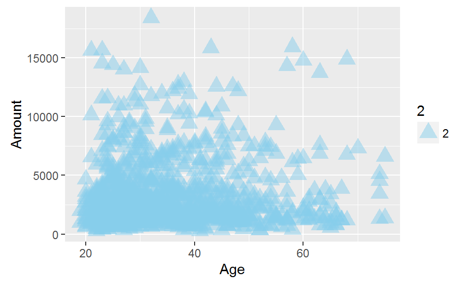

```r
ggplot(data = GermanCredit, aes(x = Age, y = Amount, size = 2)) +
  geom_point(alpha = 0.5, color = "Sky Blue", shape = 17)
```

## Test yourself

How about creating this kind of graph?

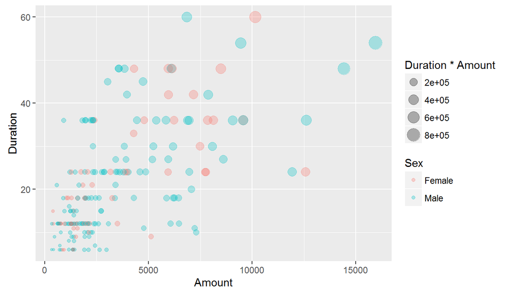

## Test yourself cd..

First step, trim the data.

```r
GermanCredit_tmp <- GermanCredit[1:200, ]
```

## Test yourself cd..

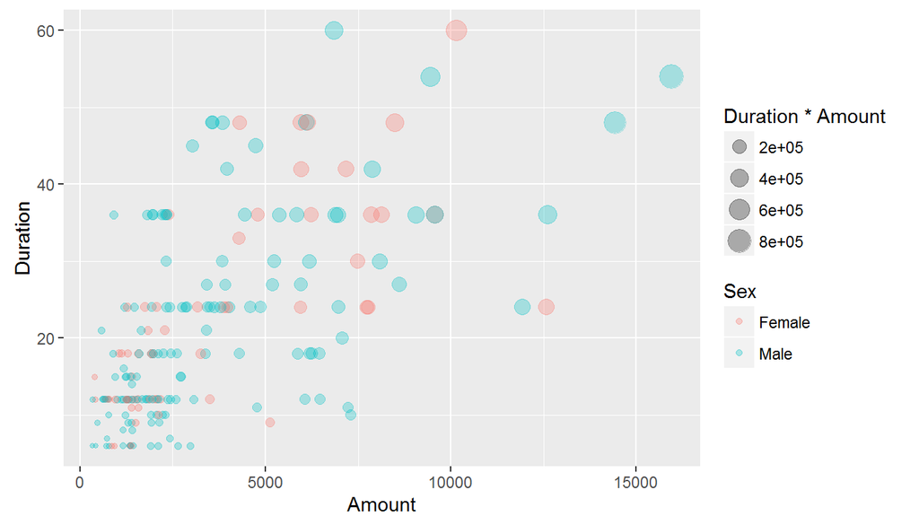

## More alterations

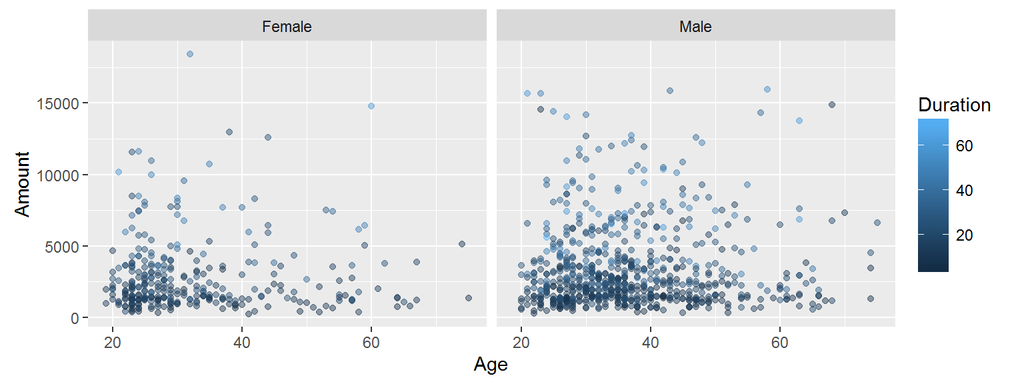

- How did the plot change?
- Are these changes based on data (i.e. can be mapped to variables in the dataset) or changes in preferences for geometric objects?

## More alterations - code

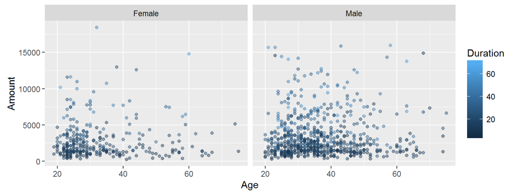

```r
ggplot(data = GermanCredit, aes(x = Age, y = Amount, color = Duration)) +
  geom_point(alpha = 0.45) +
  facet_grid(. ~ Sex)
```

## More alterations - code cd…

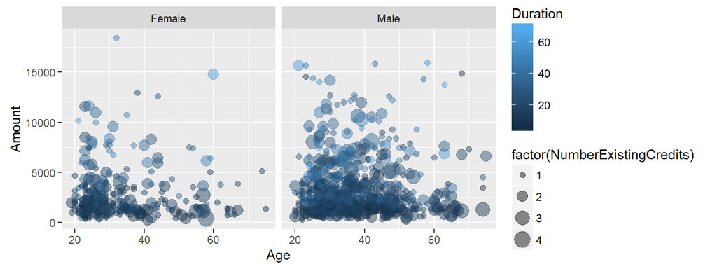

```r
ggplot(data = GermanCredit, aes(x = Age, y = Amount, color = Duration,
                                size = factor(NumberExistingCredits))) +
  geom_point(alpha = 0.45) +
  facet_grid(. ~ Sex)
```

## Anatomy of ggplots

```
ggplot(data = [dataframe], aes(x = [var_x], y = [var_y],
       color = [var_for_color], fill = [var_for_fill],
       shape = [var_for_shape])) +
    geom_[some_geom] +
    ... # other options
```

## Histograms

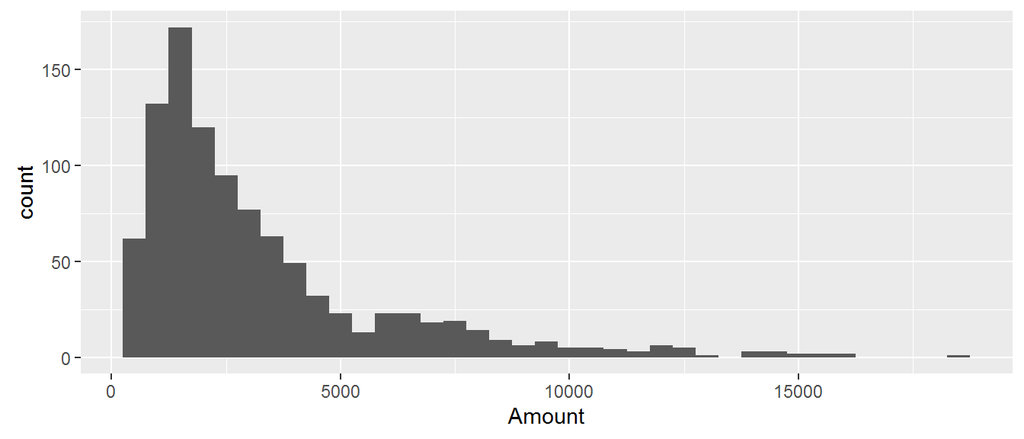

```r
ggplot(data = GermanCredit, aes(x = Amount)) +
  geom_histogram(binwidth = 500)
```

## Boxplots

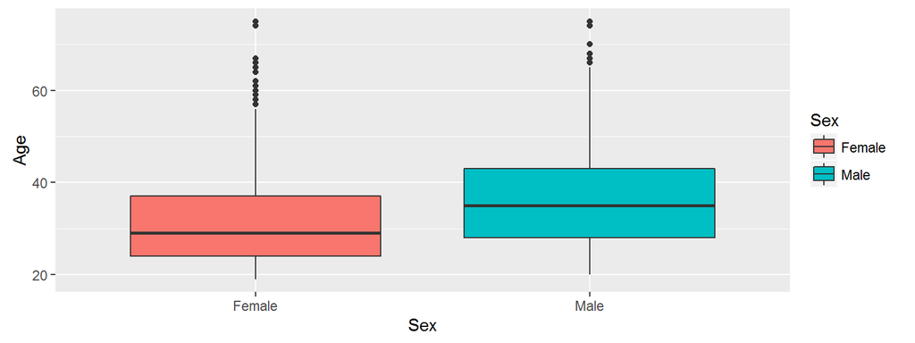

```r
ggplot(data = GermanCredit, aes(y = Age, x = Sex, fill = Sex)) +
  geom_boxplot()
```

## Barplots

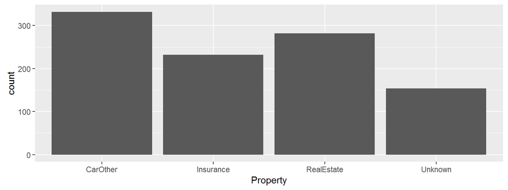

```r
ggplot(data = GermanCredit, aes(x = Property)) +
  geom_bar()
```

## Segmented barplots

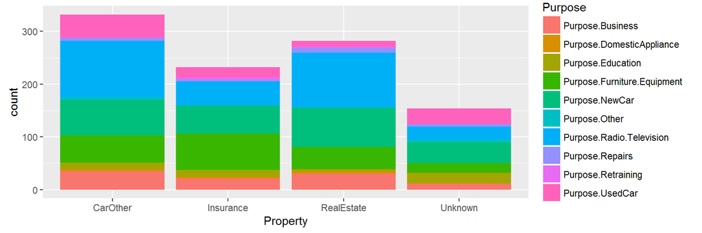

```r
ggplot(data = GermanCredit, aes(x = Property, fill = Purpose)) +
  geom_bar()
```

## Segmented barplots - proportions

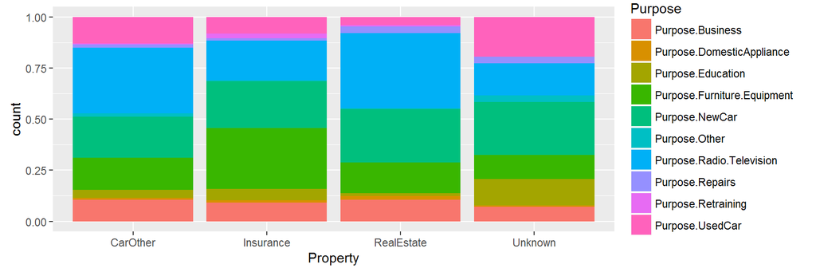

```r
ggplot(data = GermanCredit, aes(x = Property, fill = Purpose)) +
  geom_bar(position="fill")
```

## Try yourself

How about creating this kind of graph?

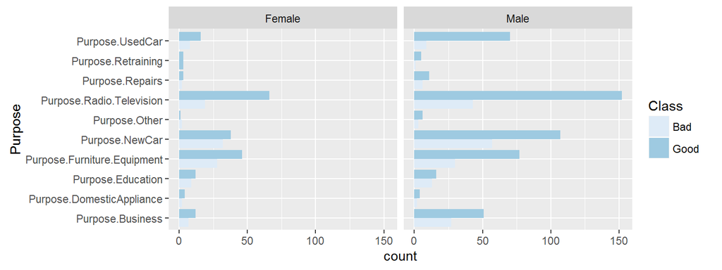

## Try yourself cd..

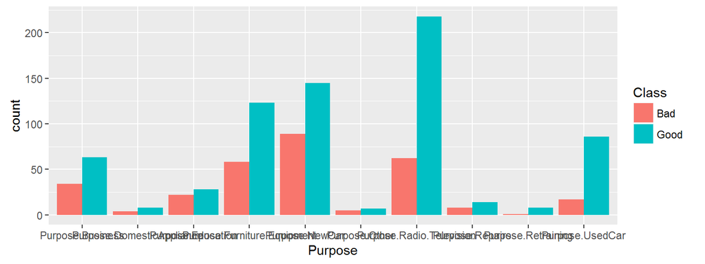

## Try yourself cd..

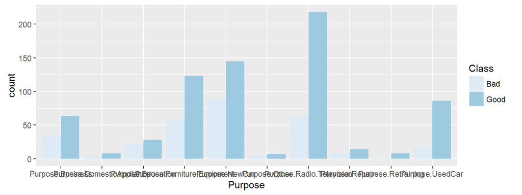

## Try yourself cd..

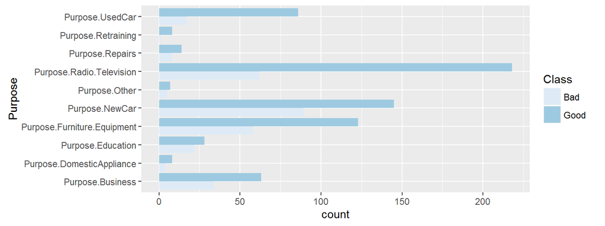

## Try yourself DONE

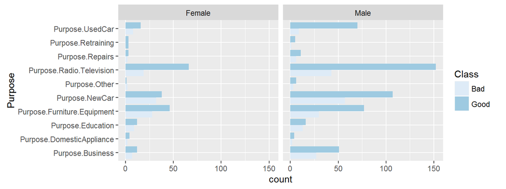

## More `ggplot2` resources

- Visit http://docs.ggplot2.org /current/ for documentation on the current version of the `ggplot2` package. It's full of examples!
- Refer to the `ggplot2` [cheatsheet](https://www.rstudio.com/wp-content/uploads/2015/08/ggplot2-cheatsheet.pdf).

## `plotly` trailer

```r
plot_ly(GermanCredit, x = Duration, y = Amount,
        text = paste("Duration: ", Duration),
        mode = "markers", color = Age, size = Duration)
```

[interactive chart not shown]

## What else can be done with R

[interactive chart not shown]

## What else can be done with R

[interactive chart not shown]

## Data wrangling

## Data wrangling in R

- Using base R functions
- Using the `dplyr` package \(\leftarrow\) our focus today
- Using a variety of other packages like `plyr`, `tidyr`, `lubridate`, etc.

## Data wrangling with `dplyr`

The `dplyr` package is based on the concepts of functions as verbs that manipulate data frames:

- `filter()`: pick rows matching criteria
- `select()`: pick columns by name
- `arrange()`: reorder rows
- `mutate()`: add new variables
- `summarise()`: reduce variables to values

## `dplyr` rules

- First argument is a data frame
- Subsequent arguments say what to do with data frame
- Always return a data frame
- Avoid modify in place

## Filter rows with `filter()`

- Select a subset of rows in a data frame.
- Easily filter for many conditions at once.

## `filter()`

```r
GermanCredit %>%
  filter(Purpose == "Purpose.Retraining") %>%
  select(Age, Amount, Sex, Class, Property)
```

```
##   Age Amount    Sex Class   Property
## 1  45    339   Male  Good   CarOther
## 2  21    902   Male   Bad  Insurance
## 3  39    932 Female  Good  Insurance
## 4  35   3447 Female  Good RealEstate
## 5  38    754   Male  Good  Insurance
## 6  36   1238   Male  Good  Insurance
## 7  27    937   Male  Good   CarOther
## 8  31   1410   Male  Good RealEstate
## 9  40    894 Female  Good  Insurance
```

## `filter()`

Credits with purpose Retraining just for males

```r
GermanCredit %>%
  filter(Purpose == "Purpose.Retraining", Sex == "Male") %>%
  select(Age, Amount, Sex, Class, Property)
```

```
##   Age Amount  Sex Class   Property
## 1  45    339 Male  Good   CarOther
## 2  21    902 Male   Bad  Insurance
## 3  38    754 Male  Good  Insurance
## 4  36   1238 Male  Good  Insurance
## 5  27    937 Male  Good   CarOther
## 6  31   1410 Male  Good RealEstate
```

## Commonly used logical operators in R

| operator | definition |
| --- | --- |
| `<` | less than |
| `<=` | less than or equal to |
| `>` | greater than |
| `>=` | greater than or equal to |
| `==` | exactly equal to |
| `!=` | not equal to |
| `x \| y` | `x` OR `y` |
| `x & y` | `x` AND `y` |

## Commonly used logical operators in R

| operator | definition |
| --- | --- |
| `is.na(x)` | test if `x` is `NA` |
| `!is.na(x)` | test if `x` is not `NA` |
| `x %in% y` | test if `x` is in `y` |
| `!(x %in% y)` | test if `x` is not in `y` |
| `!x` | not `x` |

## Aside: real data is messy!

This format of variable is not to nice, what can we do about it?

```r
GermanCredit %>%
  group_by(Purpose) %>%
  summarise(Purpose_count = n())
```

```
## Source: local data frame [10 x 2]
##
##                        Purpose Purpose_count
##                          <chr>         <int>
## 1             Purpose.Business            97
## 2    Purpose.DomesticAppliance            12
## 3            Purpose.Education            50
## 4  Purpose.Furniture.Equipment           181
## 5               Purpose.NewCar           234
## 6                Purpose.Other            12
## 7     Purpose.Radio.Television           280
## 8              Purpose.Repairs            22
## 9           Purpose.Retraining             9
## 10             Purpose.UsedCar           103
```

## Cleaning up the data!

- We're going to need to do some text parsing to clean up these data
- New R package: `stringr`

## Install and load: `stringr`

- Install:

```r
install.packages("stringr")
```

- Load:

```r
library(stringr)
```

- Package reference: Most R packages come with a vignette that describe in detail what each function does and how to use them, they're incredibly useful resources (in addition to other worked out examples on the web) https://cran.r-project.org/web/packages/stringr/vignettes/stringr.html

## Replace with `str_replace()` and add new variables with `mutate()`

- Remember we want to do the following in the `Purpose` variable: Delete Purpose prefix for all the values

```r
GermanCredit <- GermanCredit %>%
  mutate(Purpose = str_replace(Purpose, "Purpose.", ""))
```

- Note that we're overwriting existing data and columns, so be careful!
  - But remember, it's easy to revert if you make a mistake since we didn't touch the raw data, we can always reload it and start over

## Check before you move on

Always check your changes and confirm code did what you wanted it to do

```r
GermanCredit %>%
  group_by(Purpose) %>%
  summarise(Purpose_count = n())
```

```
## Source: local data frame [10 x 2]
##
##                Purpose Purpose_count
##                  <chr>         <int>
## 1             Business            97
## 2    DomesticAppliance            12
## 3            Education            50
## 4  Furniture.Equipment           181
## 5               NewCar           234
## 6                Other            12
## 7     Radio.Television           280
## 8              Repairs            22
## 9           Retraining             9
## 10             UsedCar           103
```

## `slice()` for certain row numbers

First five

```r
GermanCredit %>%
  slice(1:5)
```

```
##   Duration Amount InstallmentRatePercentage ResidenceDuration Age
## 1        6   1169                         4                 4  67
## 2       48   5951                         2                 2  22
## 3       12   2096                         2                 3  49
## 4       42   7882                         2                 4  45
## 5       24   4870                         3                 4  53
##   NumberExistingCredits NumberPeopleMaintenance Class    Sex   Property
## 1                     2                       1  Good   Male RealEstate
## 2                     1                       1   Bad Female RealEstate
## 3                     1                       2  Good   Male RealEstate
## 4                     1                       2  Good   Male  Insurance
## 5                     2                       2   Bad   Male    Unknown
##               Purpose
## 1    Radio.Television
## 2    Radio.Television
## 3           Education
## 4 Furniture.Equipment
## 5              NewCar
```

## `slice()` for certain row numbers

Last five

```r
last_row <- nrow(GermanCredit)
GermanCredit %>%
  slice((last_row-4):last_row)
```

```
##   Duration Amount InstallmentRatePercentage ResidenceDuration Age
## 1       12   1736                         3                 4  31
## 2       30   3857                         4                 4  40
## 3       12    804                         4                 4  38
## 4       45   1845                         4                 4  23
## 5       45   4576                         3                 4  27
##   NumberExistingCredits NumberPeopleMaintenance Class    Sex   Property
## 1                     1                       1  Good Female RealEstate
## 2                     1                       1  Good   Male  Insurance
## 3                     1                       1  Good   Male   CarOther
## 4                     1                       1   Bad   Male    Unknown
## 5                     1                       1  Good   Male   CarOther
##               Purpose
## 1 Furniture.Equipment
## 2             UsedCar
## 3    Radio.Television
## 4    Radio.Television
## 5             UsedCar
```

## `select()` to keep only the variables you mention

```r
GermanCredit %>%
  select(Class, Sex) %>%
  table()
```

```
##       Sex
## Class  Female Male
##   Bad     109  191
##   Good    201  499
```

## or `select()`to exclude variables

```r
GermanCredit %>%
  select(-Property) %>%
  slice(1:5)
```

```
##   Duration Amount InstallmentRatePercentage ResidenceDuration Age
## 1        6   1169                         4                 4  67
## 2       48   5951                         2                 2  22
## 3       12   2096                         2                 3  49
## 4       42   7882                         2                 4  45
## 5       24   4870                         3                 4  53
##   NumberExistingCredits NumberPeopleMaintenance Class    Sex
## 1                     2                       1  Good   Male
## 2                     1                       1   Bad Female
## 3                     1                       2  Good   Male
## 4                     1                       2  Good   Male
## 5                     2                       2   Bad   Male
##               Purpose
## 1    Radio.Television
## 2    Radio.Television
## 3           Education
## 4 Furniture.Equipment
## 5              NewCar
```

## `rename()` specific columns

Correct typos and rename to make variable names shorter and/or more informative

- Original names:

```r
names(GermanCredit)
```

```
##  [1] "Duration"                  "Amount"
##  [3] "InstallmentRatePercentage" "ResidenceDuration"
##  [5] "Age"                       "NumberExistingCredits"
##  [7] "NumberPeopleMaintenance"   "Class"
##  [9] "Sex"                       "Property"
## [11] "Purpose"
```

- Rename `Sex` to `Gender`:

```r
GermanCredit <- GermanCredit %>%
  rename(Gender = Sex)
```

## Check before you move on

Always check your changes and confirm code did what you wanted it to do

```r
names(GermanCredit)
```

```
##  [1] "Duration"                  "Amount"
##  [3] "InstallmentRatePercentage" "ResidenceDuration"
##  [5] "Age"                       "NumberExistingCredits"
##  [7] "NumberPeopleMaintenance"   "Class"
##  [9] "Gender"                    "Property"
## [11] "Purpose"
```

## `summarise()` in a new data frame

```r
GermanCredit %>%
  group_by(Purpose) %>%
  summarise(count = n()) %>%
  arrange(count)
```

```
## Source: local data frame [10 x 2]
##
##                Purpose count
##                  <chr> <int>
## 1           Retraining     9
## 2    DomesticAppliance    12
## 3                Other    12
## 4              Repairs    22
## 5            Education    50
## 6             Business    97
## 7              UsedCar   103
## 8  Furniture.Equipment   181
## 9               NewCar   234
## 10    Radio.Television   280
```

## and `arrange()` to order rows

```r
GermanCredit %>%
  group_by(Purpose) %>%
  summarise(count = n()) %>%
  arrange(desc(count))
```

```
## Source: local data frame [10 x 2]
##
##                Purpose count
##                  <chr> <int>
## 1     Radio.Television   280
## 2               NewCar   234
## 3  Furniture.Equipment   181
## 4              UsedCar   103
## 5             Business    97
## 6            Education    50
## 7              Repairs    22
## 8    DomesticAppliance    12
## 9                Other    12
## 10          Retraining     9
```

## More `dplyr` resources

- Visit https://cran.r-project.org/web/packages/dplyr/vignettes/introduction.html for the package vignette.
- Refer to the `dplyr` [cheatsheet](https://www.rstudio.com/wp-content/uploads/2015/02/data-wrangling-cheatsheet.pdf).

## Basic R syntax

## Few important R syntax notes

For when not working with `dplyr` or `ggplot2`

- Refer to a variable in a dataset as `GermanCredit$Class`
- Access any element in a dataframe using square brackets

```r
GermanCredit <- as.data.frame(GermanCredit)
GermanCredit[1,5] # row 1, column 5
```

```
## [1] 67
```

```
- For all observations in row 1: `GermanCredit[1, ]`
- For all observations in column 5: `GermanCredit[, 5]`
```

## What's next?

## Want more R?

- Local install
  - R: https://cran.r-project.org/
  - RStudio: https://www.rstudio.com/products/RStudio/#Desktop
- Resources for learning R:
  - [Coursera](https://www.coursera.org/)
  - [DataCamp](https://www.datacamp.com/)
  - Many many online demos, resources, examples, as well as books
- Debugging R errors:
  - Read the error!
  - [StackOverflow](http://stackoverflow.com/)
- Keeping up with what's new in R land:
  - [R-bloggers](http://www.r-bloggers.com/)
  - Twitter: #rstats

## More materials

- [List of useful packages](https://support.rstudio.com/hc/en-us/articles/201057987-Quick-list-of-useful-R-packages)
- [Shiny tutorial](http://shiny.rstudio.com/tutorial/lesson1/)
- [Cheatsheets](https://www.rstudio.com/resources/cheatsheets/)
- [ggplot2 compendium](http://docs.ggplot2.org/current/)
- [dplyr tutorial](https://www.dropbox.com/sh/i8qnluwmuieicxc/AAAgt9tIKoIm7WZKIyK25lh6a)
- [ggplot2 tutorial](http://www.education.umd.edu/EDMS/fac/Harring/769L-Spring-2016/Resources/R-Resources/ggplot2-tutorial.pdf)
- [visualizations htmlwidgets](http://gallery.htmlwidgets.org/)
- [visualizations metricgraphics](http://hrbrmstr.github.io/metricsgraphics/)
- [visualizations plotly](https://plot.ly/r/)

## Useful Georgian read.csv

- [Github page Jean-Sebastien Gourdet](https://github.com/geojsg/GeorgianUnicode)

## Questions

## Exercise

## Your turn

Create a new dataframe that doesn't include observations where `Purpose = Other` since it's not clear what this means.

This new dataframe also should include observations for Man only, and for people older than 40 and younger than 60

Summarize the number of Good and Bad credits for each grup of `Property` arrange the table descending order.

Create a visualization that will help answer which Married status is the most probable to have bad credits for whole data set.

## Contact

- Janek Idziak Jan.Idziak@gmail.com
- Michal Krason michal.krason1@gmail.com